# Lista03_MQ101_CerveraCelia

# (5) Simulação I (correlação):

três níveis de correlação (ρ = 0.2,0.6,0.9); faça três dispersões; compare.

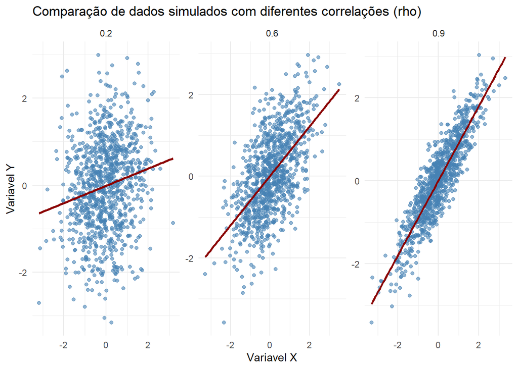

```r
n <- 1000
  rhos <- c(0.2, 0.6, 0.9)              #correlação Pearson/ correlação lineal


  sim <- purrr::map_dfr(rhos, \(rho) {
  x <- rnorm(n); e <- rnorm(n)
  y <- rho*x + sqrt(1 - rho^2)*e
  tibble(rho = rho, x = x, y = y)
  })


  ggplot(sim, aes(x = x, y = y)) +
    geom_point(alpha = 0.6, color = "steelblue") +
    geom_smooth(method = "lm", se = FALSE, color = "darkred") +
    facet_wrap(~ rho, scales = "free") + # Separar por rho
    labs(
      title = "Comparação de dados simulados com diferentes correlações (rho)",
      x = "Variavel X",
      y = "Variavel Y"
    ) +
    theme_minimal()
```

# (6) Simulação II (grupos): duas distribuições com médias/variancias diferentes; histogramas/densidades/boxplot/violin.

Passos. Simule grupo A: N (0, 1); grupo B: N (1, 1.8);faça histogramas/densidades/boxplot/violin; interprete.

```r
n <- 1000
  df_grupos <- tibble(grupo = rep(c("A","B"),
                each = n), valor = c(rnorm(n, 0, 1), rnorm(n, 1, 1.8)))
```

### HISTOGRAMA

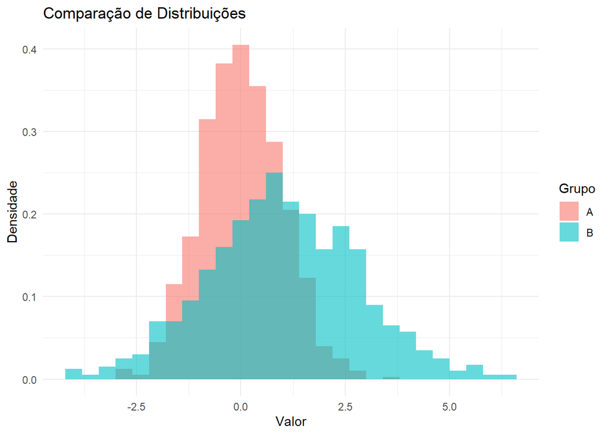

```r
ggplot(df_grupos, aes(x = valor, fill = grupo)) +
         geom_histogram(aes(y = after_stat(density)),
                        binwidth = 0.4, alpha = 0.6, position = "identity") +
      labs(
      title = "Comparação de Distribuições",
         x = "Valor",
         y = "Densidade",
      fill = "Grupo"  ) +
    theme_minimal()
```

### DENSIDADE

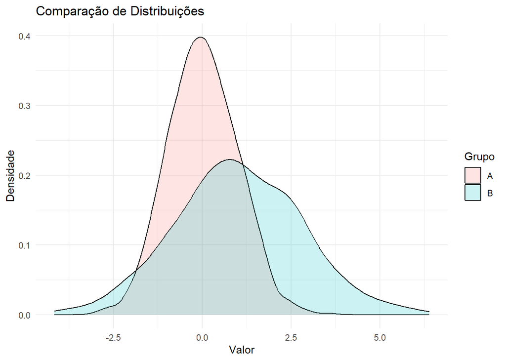

```r
ggplot(df_grupos, aes(x = valor, fill = grupo)) +
    geom_density(alpha = 0.2) +
    labs(
      title = "Comparação de Distribuições",
      x = "Valor",
      y = "Densidade",
      fill = "Grupo"  ) +
    theme_minimal()
```

#### BOXPLOT

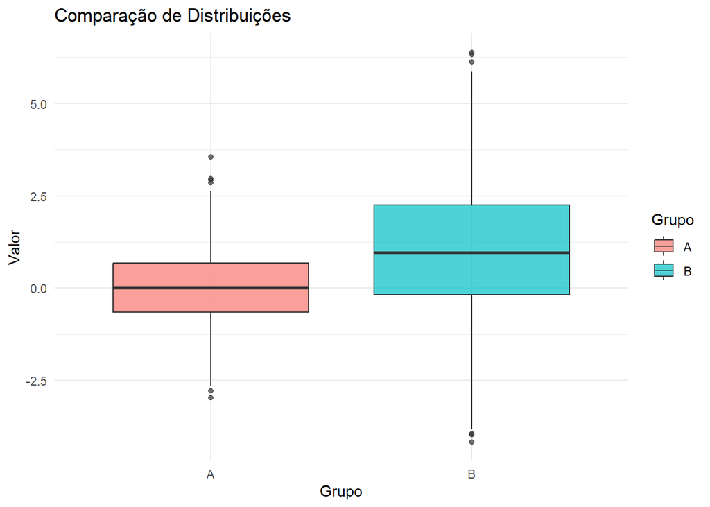

```r
ggplot(df_grupos, aes(x = grupo, y = valor, fill = grupo)) +
    geom_boxplot(alpha = 0.7) +
      labs(
      title = "Comparação de Distribuições",
      x = "Grupo",
      y = "Valor",
      fill = "Grupo"
    ) +
    theme_minimal()
```

### VIOLIN

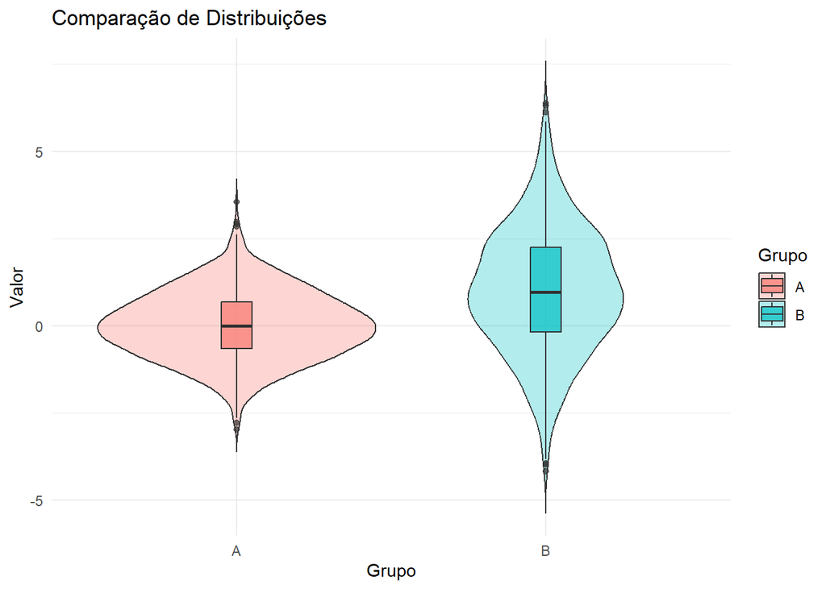

```r
ggplot(df_grupos, aes(x = grupo, y = valor, fill = grupo)) +
  geom_violin(alpha = 0.3, trim = FALSE) +
    geom_boxplot(width= 0.1,alpha = 0.7) +
   labs(
      title = "Comparação de Distribuições",
      x = "Grupo",
      y = "Valor",
      fill = "Grupo"
    ) +
    theme_minimal()
```

### Interpretação:

O grupo A tem valores mais concentrados em torno de 0, enquanto no grupo B os dados estão mais dispersos e deslocados para a direita. Embora os valores se sobreponham, observa-se uma tendência para valores mais elevados no grupo B.

# (8) educ_saude - explorar gráficos

```r
  library(readr)
    educ <- read_csv(file.choose())
    glimpse(educ)
```

```
## Rows: 10,000
## Columns: 13
## $ id                <chr> "P00001", "P00002", "P00003", "P00004", "P00005", "P…
## $ sexo              <chr> "M", "F", "F", "F", "F", "F", "F", "F", "F", "F", "M…
## $ escolaridade      <chr> "Médio", "Médio", "Médio", "Médio", "Médio", "Médio"…
## $ anos_estudo       <dbl> 10, 9, 9, 10, 11, 11, 10, 8, 15, 11, 6, 7, 5, 4, 10,…
## $ rede_escolar      <chr> "privada", "pública", "pública", "pública", "pública…
## $ municipio         <chr> "Santos", "Dourados", "Várzea Grande", "Curitiba", "…
## $ UF                <chr> "SP", "MS", "MT", "PR", "RJ", "SP", "SC", "SP", "SP"…
## $ idade             <dbl> 39, 30, 31, 44, 26, 51, 47, 48, 25, 53, 23, 27, 35, …
## $ faltas_esc        <dbl> 0, 0, 1, 0, 1, 0, 1, 0, 1, 0, 0, 0, 0, 0, 2, 0, 0, 0…
## $ tempo_estudo_h    <dbl> 2.3, 6.6, 8.8, 4.2, 3.7, 4.9, 0.2, 1.9, 14.4, 3.3, 3…
## $ pressao_sistolica <dbl> 110, 109, 121, 131, 134, 124, 139, 124, 132, 134, 13…
## $ diagnostico       <chr> "sem", "sem", "sem", "sem", "sem", "HAS", "sem", "se…
## $ plano_saude       <chr> "privado", "privado", "nenhum", "nenhum", "SUS", "pr…
```

### HISTOGRAMA

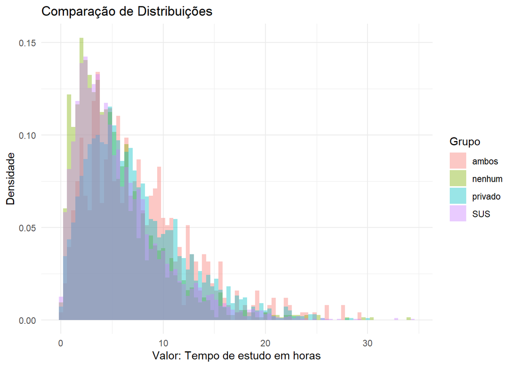

```r
ggplot(educ, aes(x = tempo_estudo_h, fill = plano_saude)) +
      geom_histogram(aes(y = after_stat(density)),
                     binwidth = 0.4, alpha = 0.4, position = "identity") +
      labs(
        title = "Comparação de Distribuições",
        x = "Valor: Tempo de estudo em horas",
        y = "Densidade",
        fill = "Grupo") +
      theme_minimal()
```

### DENSIDAD

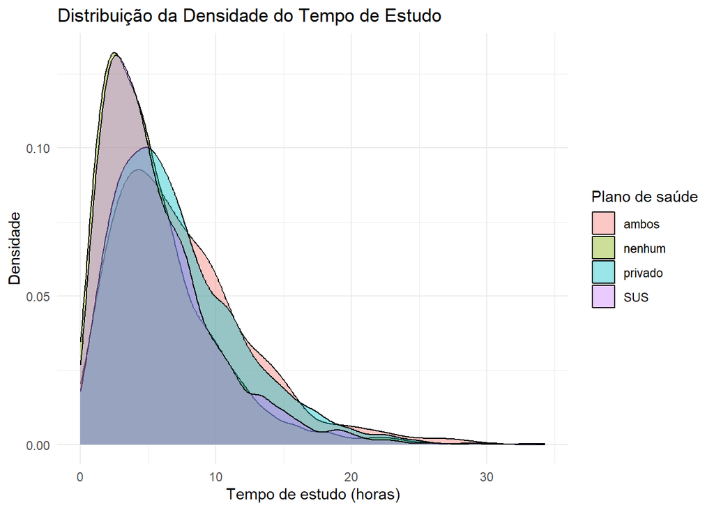

```r
ggplot(educ, aes(x = tempo_estudo_h, fill = plano_saude)) +
      geom_density(alpha = 0.4) +
      labs(
        title = "Distribuição da Densidade do Tempo de Estudo",
        x = "Tempo de estudo (horas)",
        y = "Densidade",
        fill = "Plano de saúde"
      ) +
      theme_minimal()
```

### BOXPLOT

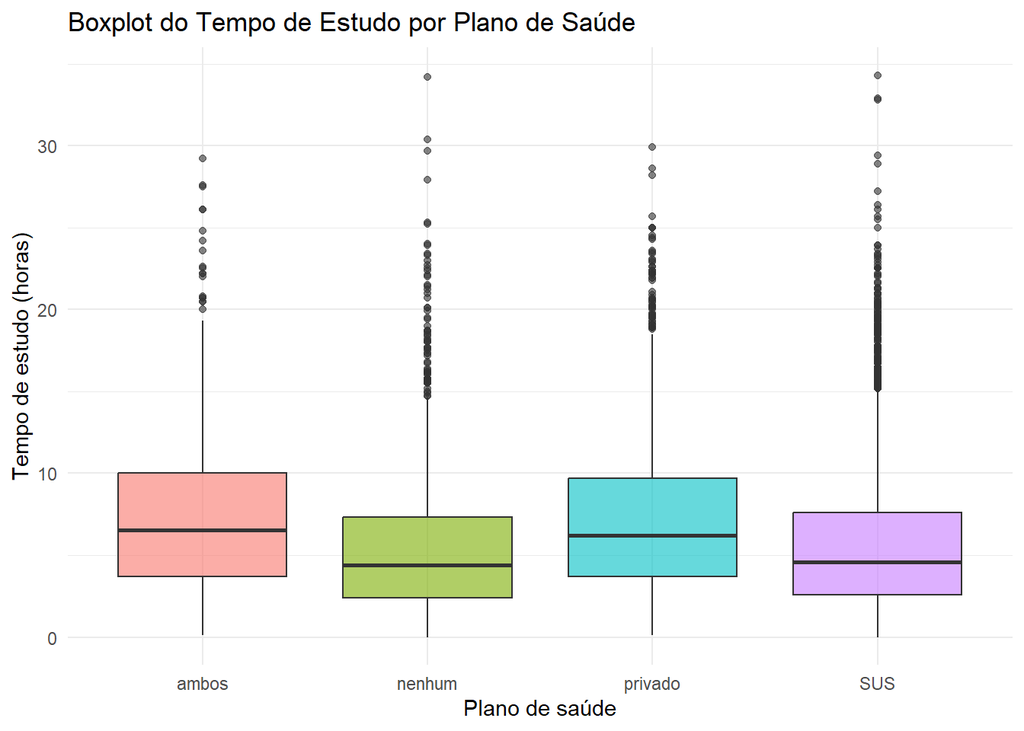

```r
ggplot(educ, aes(x = plano_saude, y = tempo_estudo_h, fill= plano_saude)) +
      geom_boxplot(alpha = 0.6) +
      labs(
        title = "Boxplot do Tempo de Estudo por Plano de Saúde",
        x = "Plano de saúde",
        y = "Tempo de estudo (horas)",
        fill = "Plano de saúde"
      ) +
      theme_minimal()+
     theme(legend.position = "none")
```

### VIOLIN

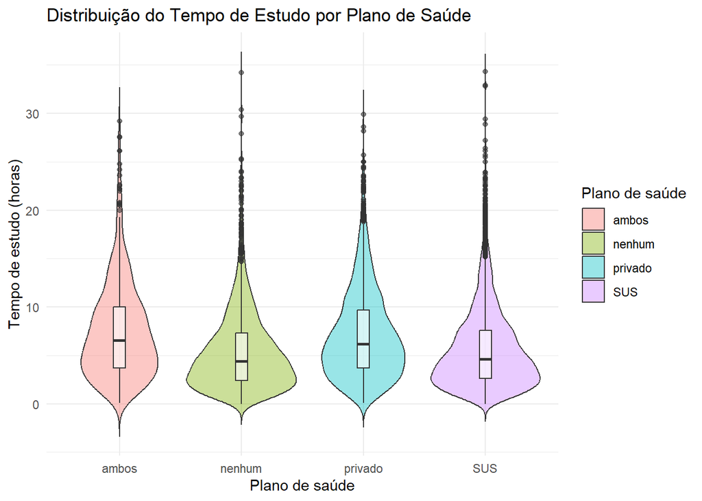

```r
ggplot(educ, aes(x = plano_saude, y = tempo_estudo_h, fill = plano_saude)) +
      geom_violin(trim = FALSE, alpha = 0.4) +
      geom_boxplot(width = 0.1, fill = "white", alpha = 0.6) +
      labs(
        title = "Distribuição do Tempo de Estudo por Plano de Saúde",
        x = "Plano de saúde",
        y = "Tempo de estudo (horas)",
        fill = "Plano de saúde"
      ) +
      theme_minimal()
```

```r
      theme(legend.position = "none")
```

```
## <theme> List of 1
##  $ legend.position: chr "none"
##  @ complete: logi FALSE
##  @ validate: logi TRUE
```

# Interpretação:

Foi analisada a relação entre o tempo de estudo em horas e o tipo de plano de saúde dos estudantes. O histograma mostra que os dados estão concentrados abaixo das 10 horas de estudo para todas as coberturas de saúde. No gráfico boxplot e violino, observa-se que os estudantes sem cobertura de saúde e os estudantes com SUS mantêm uma quantidade menor de horas de estudo; no entanto, não é possível estabelecer uma relação entre os hábitos de estudo e a cobertura de saúde do estudante.